# Deep Dive Sentinel 2 labels for training set

ROSSyndicate

2024-04-22

# Purpose

This script takes a deep dive into Sentinel 2 labels for a more rigorous analysis of inconsistent band data and outliers in the filtered label dataset. Here we will determine if any more label data points should be removed from the training dataset and whether or not we can glean anything from the metadata in the outlier dataset to be able to pre-emptively toss out scenes when we go to apply the classification algorithm.

```r
harmonize_version = "v2024-04-17"
outlier_version = "v2024-04-17"

S2 <- read_rds(paste0("data/labels/harmonized_SEN2_labels_", harmonize_version, ".RDS"))
```

## Check for mis-matched band data between user data and re-pull

Just look at the data to see consistent (or inconsistent) user-pulled data and our pull, here, our user data are in “BX” format and the re-pull is in “SR_BX” format. These are steps to assure data quality if the volunteer didn’t follow the directions explicitly.

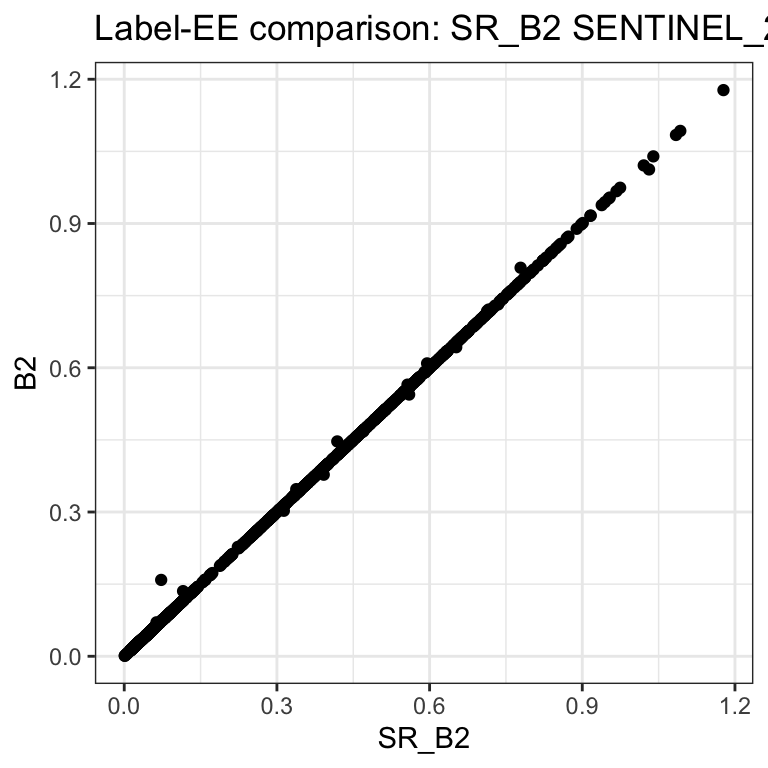

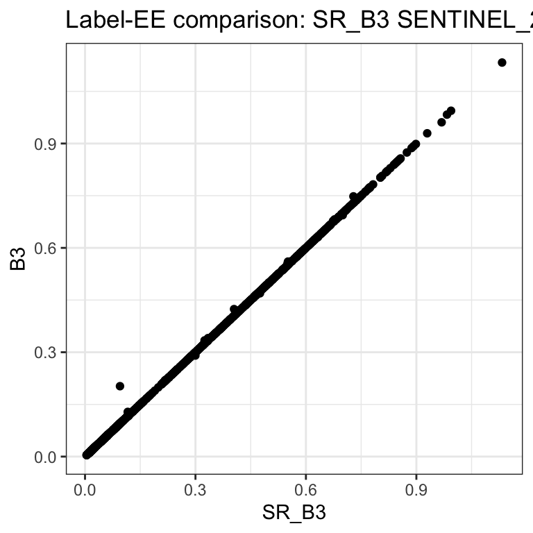

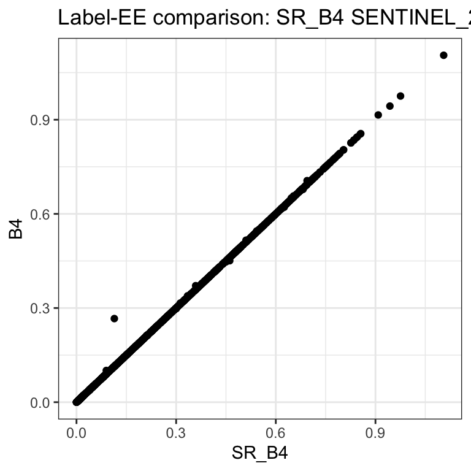

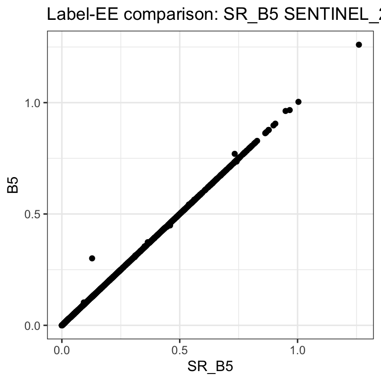

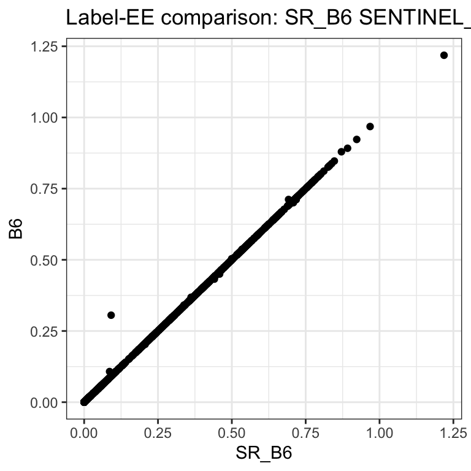

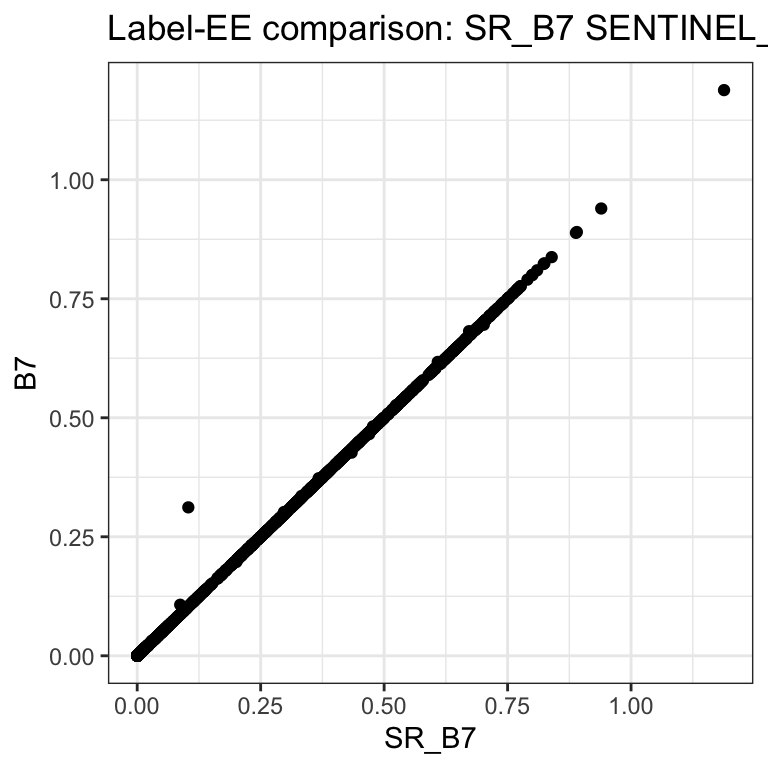

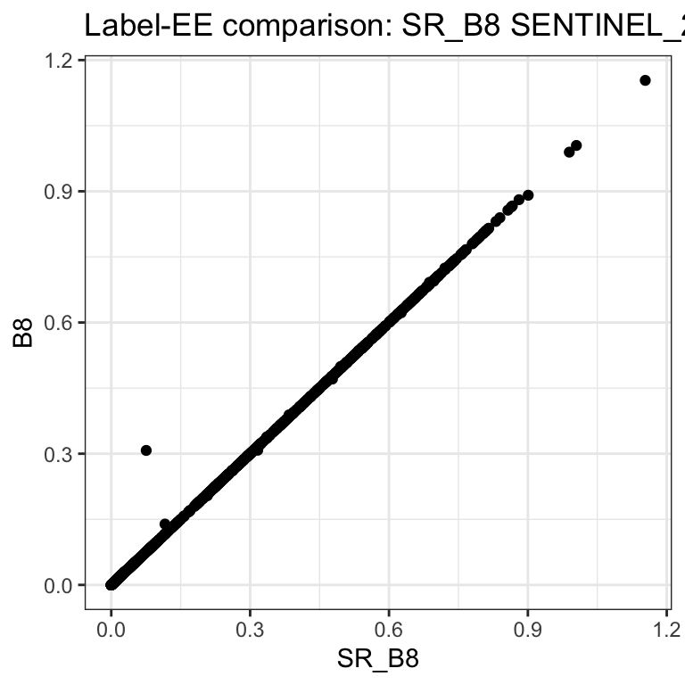

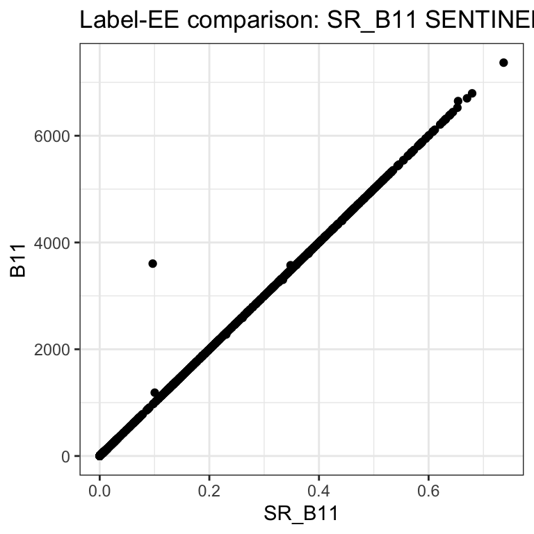

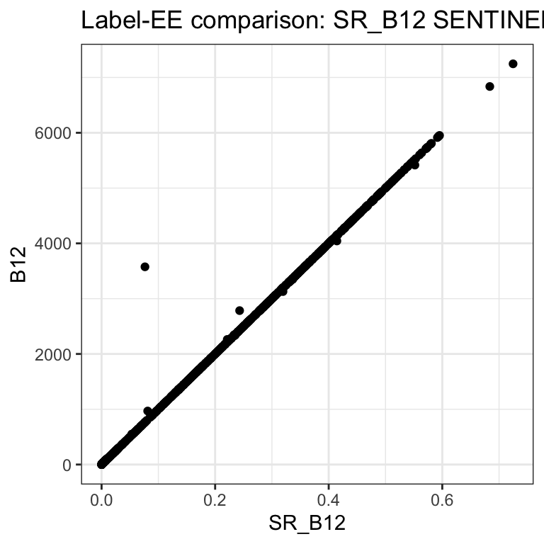

```r
pmap(.l = list(user_band = S2_user,
               ee_band = S2_ee,
               data = list(S2),
               mission = list("SENTINEL_2")),
     .f = make_band_comp_plot)
```

There isn’t a ton of mis-match here, we’ll just use B3/SR_B3 as a reference to filter inconsistent labels

```r
S2_inconsistent <- S2 %>%
  filter(SR_B3 != B3)

S2_inconsistent %>%
  group_by(class) %>%
  summarise(n_labels = n()) %>%
  kable()
```

| class | n_labels |
| --- | --- |
| cloud | 21 |
| darkNearShoreSediment | 1 |
| lightNearShoreSediment | 1 |
| offShoreSediment | 3 |
| openWater | 14 |
| other | 3 |
| shorelineContamination | 1 |

We should see if there is any common contributor or scene here. There were no data handling differences between the user-pull and our second pull, so we can’t dismiss the cloud differences.

```r
S2_inconsistent %>%
  group_by(vol_init) %>%
  summarise(n_dates = length(unique(date)),
            n_labels = n()) %>%
  kable()
```

| vol_init | n_dates | n_labels |
| --- | --- | --- |
| ANK | 7 | 10 |
| BJM | 7 | 17 |
| JFL | 1 | 1 |
| LRCP | 3 | 9 |
| SKS | 2 | 4 |
| TJB | 1 | 3 |

The inconsistencies are spread across many dates, so I don’t think there is any special handling necessary here except for removing these from the dataset.

```r
S2_filtered <- S2 %>%
  filter(# filter data where SR_B3/B3 match
         SR_B3 == B3,
         # or where any re-pulled band value is greater than 1, which isn't a valid value
         if_all(S2_ee,
                ~ . <= 1))
```

And plot:

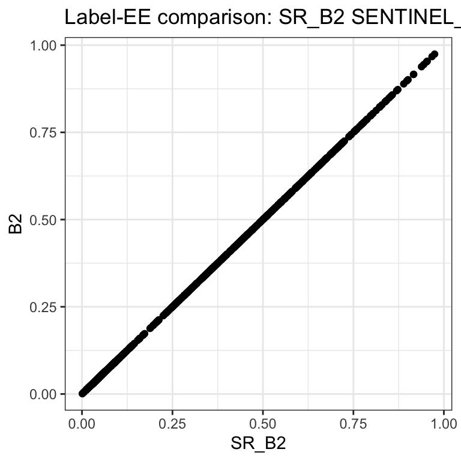

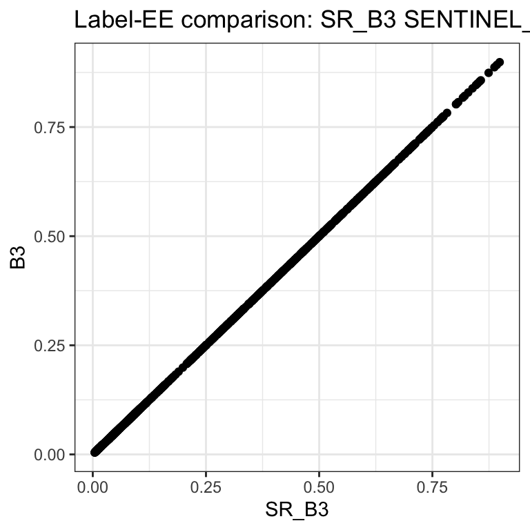

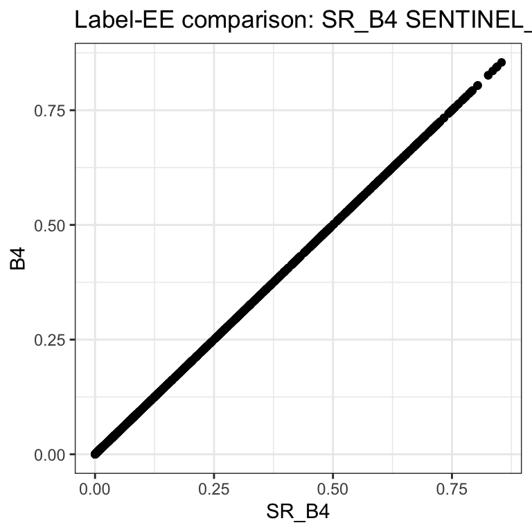

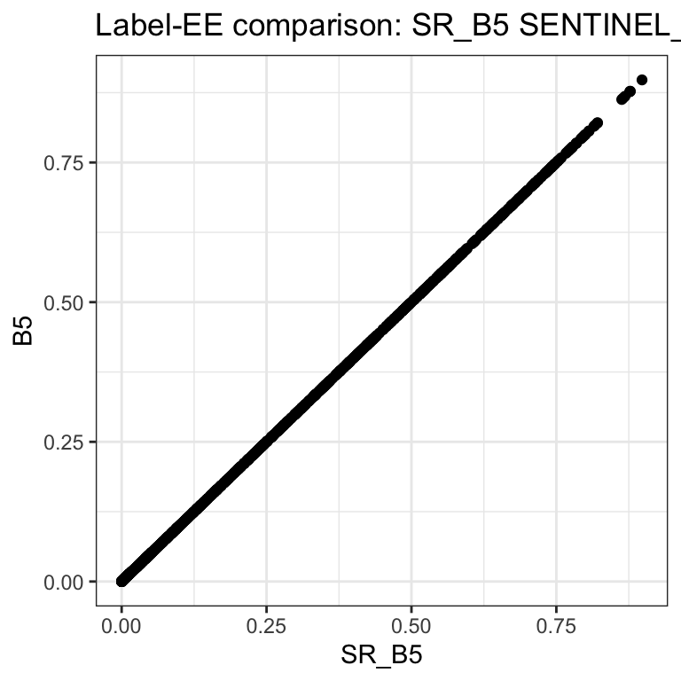

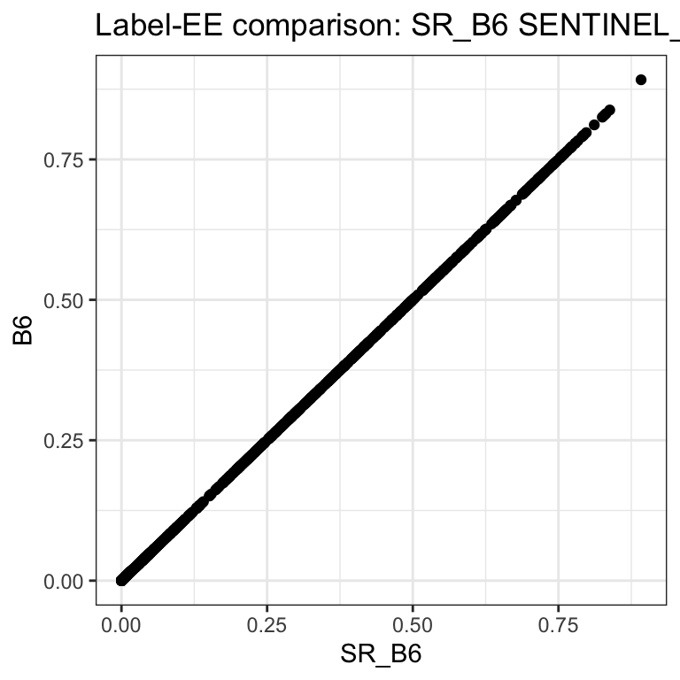

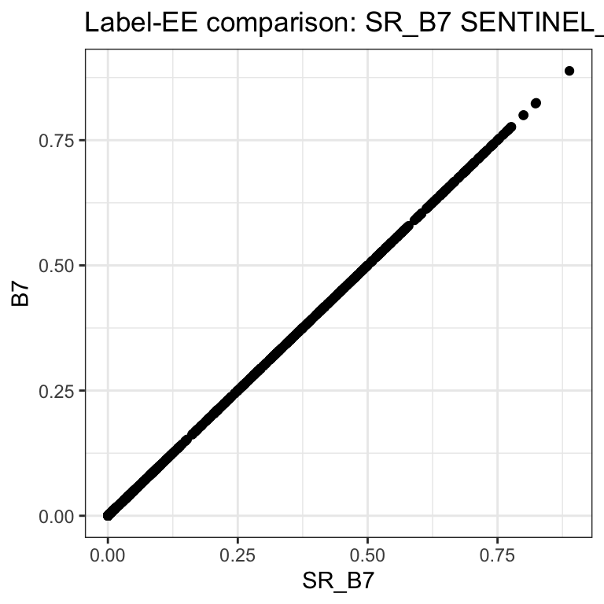

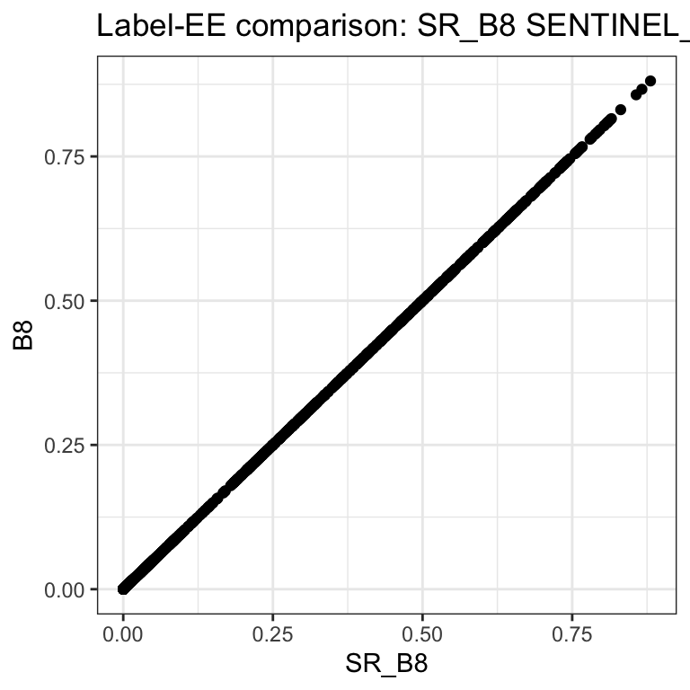

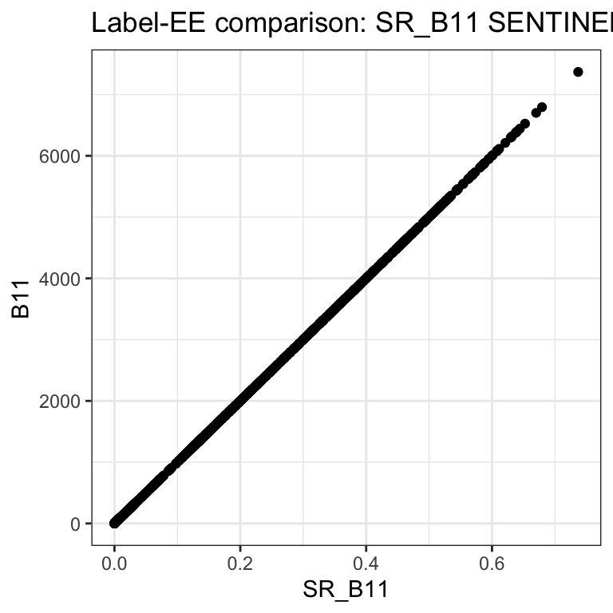

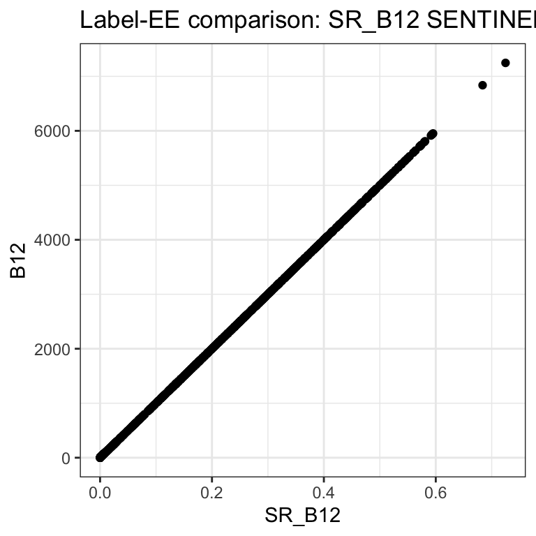

Looks good!

And now let’s look at the data by class:

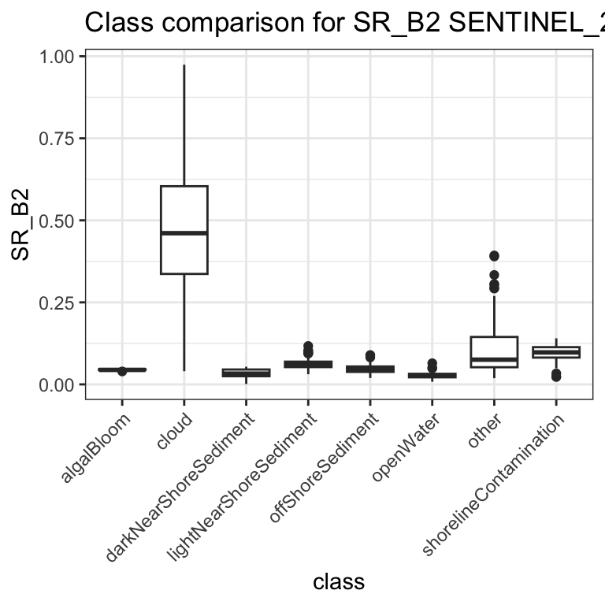

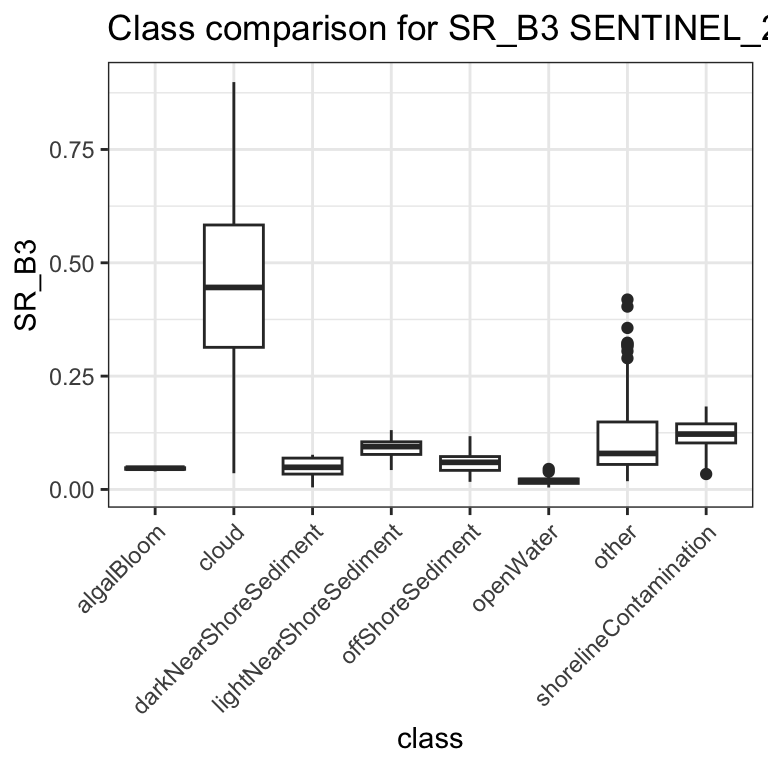

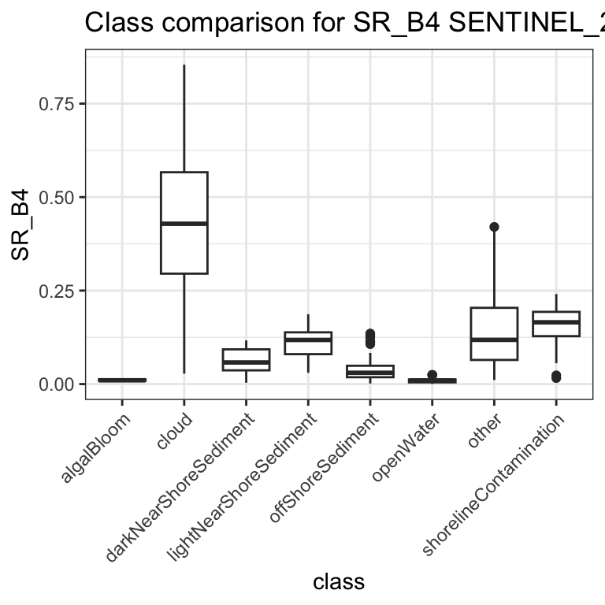

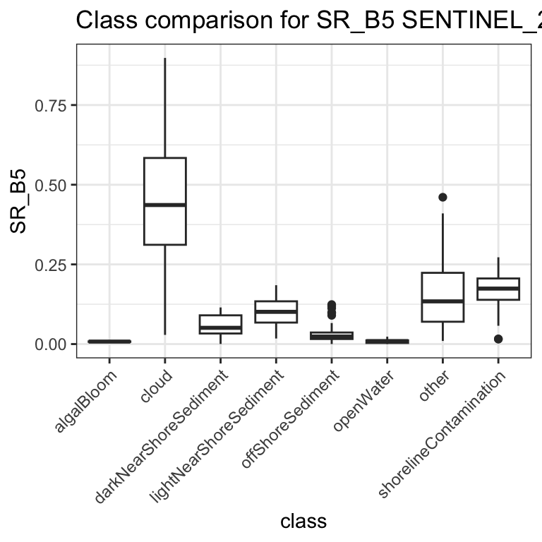

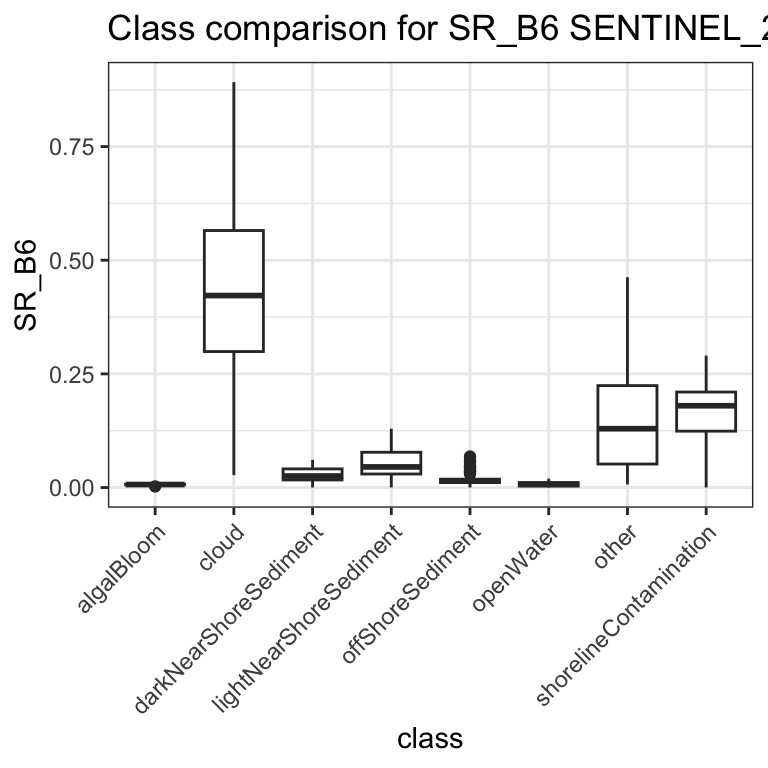

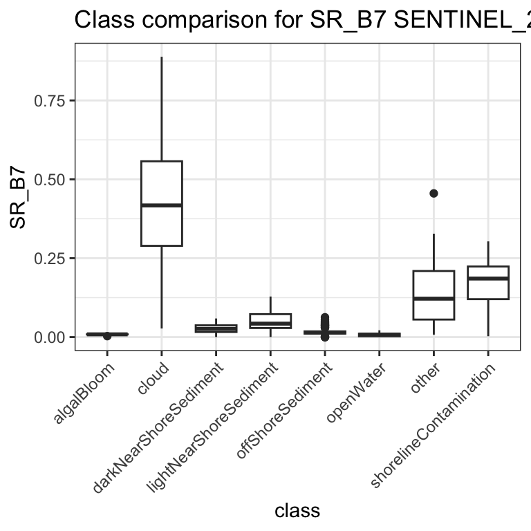

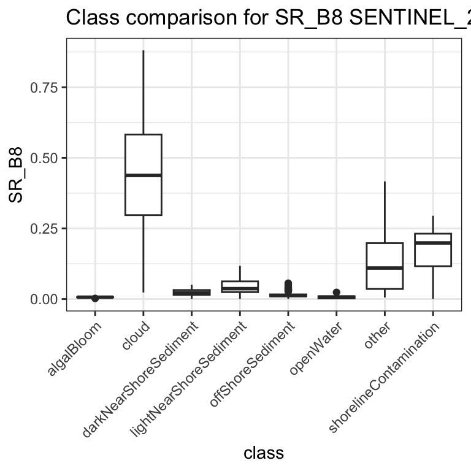

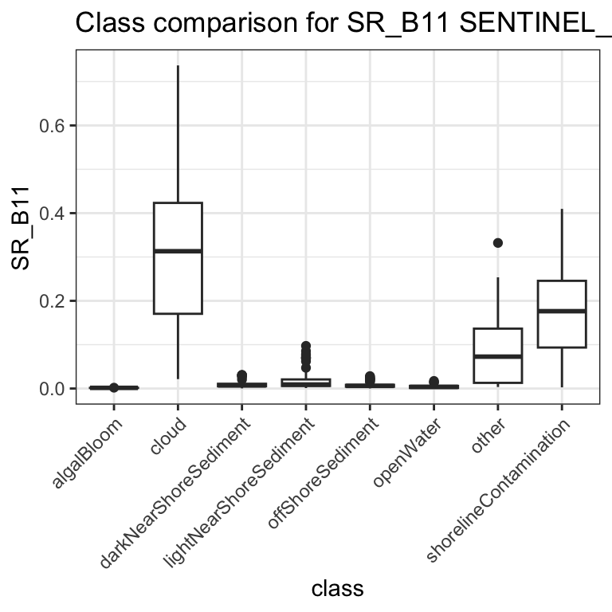

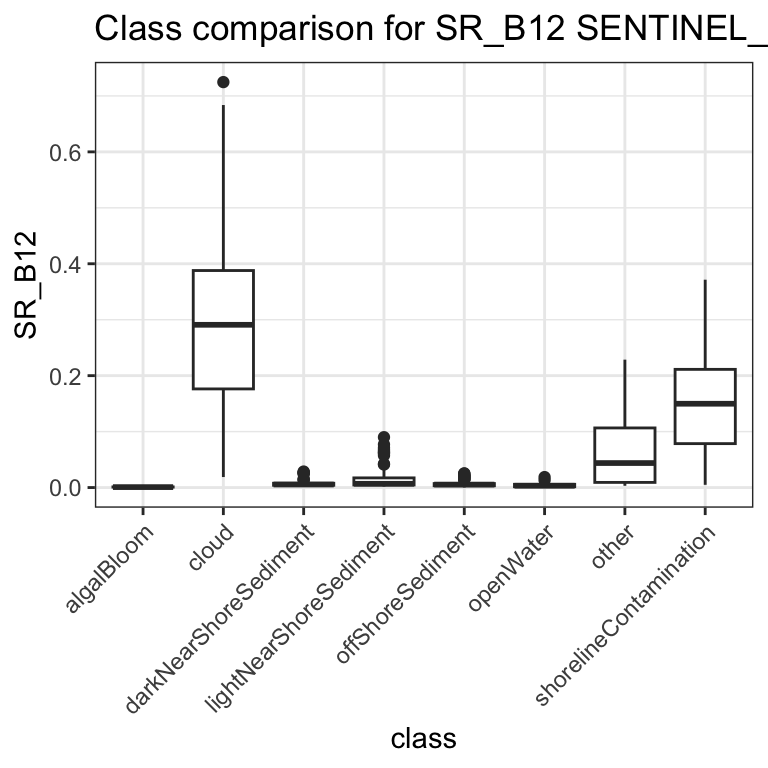

We aren’t actually modeling “other” (not sufficient observations to classify) or “shorelineContamination” (we’ll use this later to block areas where there is likely shoreline contamination in the AOI). Additionally, “algalBloom” is likely a processing issue, and n is too low to use that data, so we’ll drop that class as well.

```r
S2_for_class_analysis <- S2_filtered %>%
  filter(!(class %in% c("other", "shorelineContamination", "algalBloom")))
```

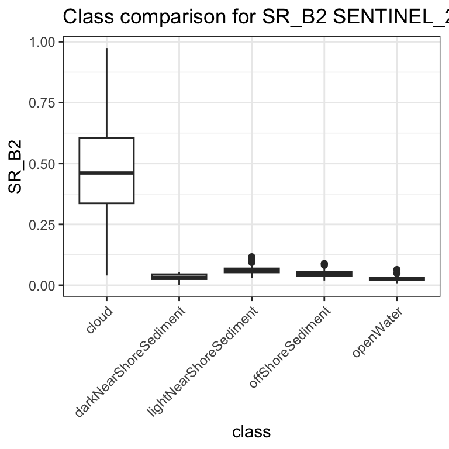

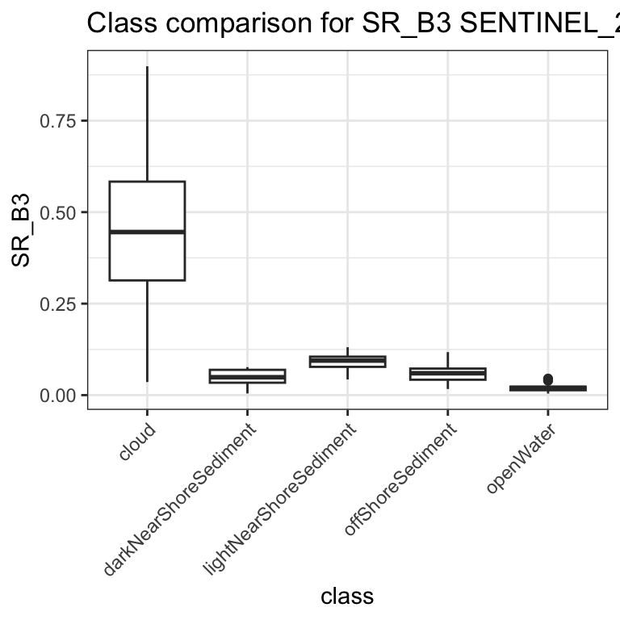

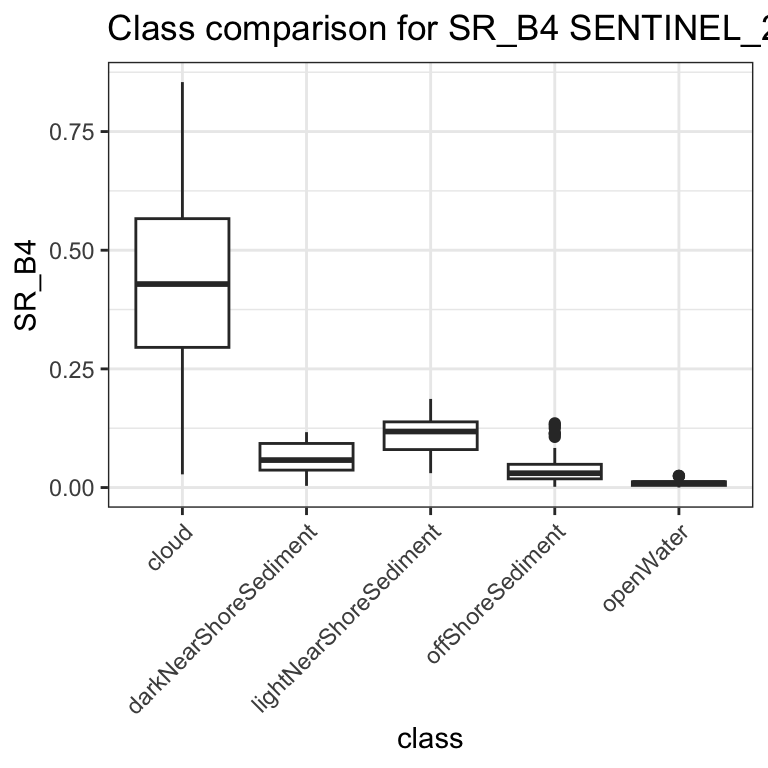